# R4DS_2E_communication

Martin

2026-01-19

## Communication - Labels

1. Create one plot on the fuel economy data with customized title, subtitle, caption, x, y, and color labels.

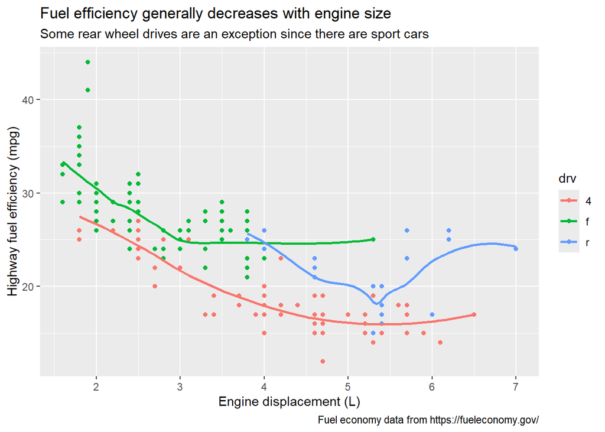

```r
ggplot(mpg, aes(displ, hwy, color = drv)) +
  geom_point() +
  geom_smooth(se = FALSE) +
  labs(
    title = "Fuel efficiency generally decreases with engine size",
    subtitle = "Some rear wheel drives are an exception since there are sport cars",
    caption = "Fuel economy data from https://fueleconomy.gov/",
    x = "Engine displacement (L)",
    y = "Highway fuel efficiency (mpg)"
  )
```

2. Recreate the following plot using the fuel economy data. Note that both the colors and shapes of points vary by type of drive train.

[figure not shown]

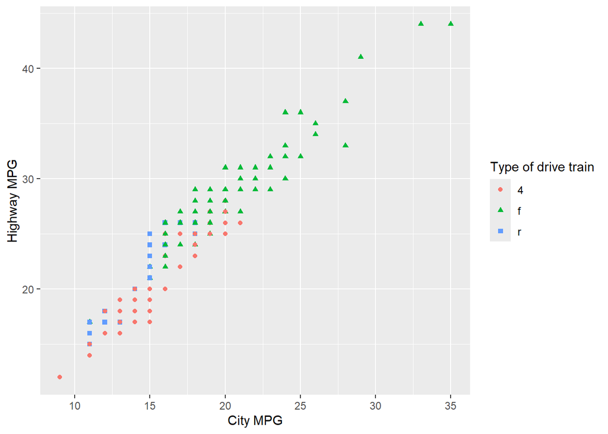

```r
ggplot(mpg, aes(cty, hwy, color = drv, shape = drv)) +
  geom_point() +
  labs(
    x = "City MPG",
    y = "Highway MPG",
    color = "Type of drive train",
    shape = "Type of drive train"
  )
```

3. Take an exploratory graphic that you’ve created in the last month, and add informative titles to make it easier for others to understand.

```r
# Leaving this here for possibly another time
```

## Communication - Annotations

1. Use geom_text() with infinite positions to place text at the four corners of the plot.

```r
last_plot <- ggplot(mpg, aes(hwy, cty)) +
  geom_point() +
  geom_text(
    label = "Top left",
    x = -Inf,
    y = Inf,
    hjust = 0,
    vjust = 1
  ) +
  geom_text(
    label = "Top right",
    x = Inf,
    y = Inf,
    hjust = 1,
    vjust = 1
  ) +
  geom_text(
    label = "Bottom right",
    x = Inf,
    y = -Inf,
    hjust = 1,
    vjust = 0
  ) +
  geom_text(
    label = "Bottom left",
    x = -Inf,
    y = -Inf,
    hjust = 0,
    vjust = 0
  )
```

2. Use annotate() to add a point geom in the middle of your last plot without having to create a tibble. Customize the shape, size, or color of the point.

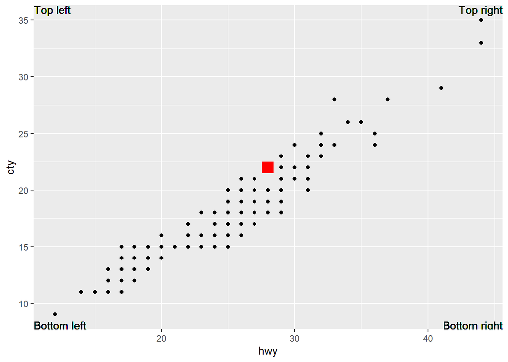

```r
# Look above for the last plot used. I'm going to extract the range values of the plot. You can check the code piecemeal to see how I'm extracting the values:
x_max <- layer_scales(last_plot)$x$range$range[2]
x_min <- layer_scales(last_plot)$x$range$range[1]
y_max <- layer_scales(last_plot)$y$range$range[2]
y_min <- layer_scales(last_plot)$y$range$range[1]

last_plot +
  annotate(
    geom = "point",
    x = (x_max + x_min) / 2, y = (y_max + y_min) / 2,
    color = "red", shape = 15, size = 5
  )
```

3. How do labels with geom_text() interact with faceting? How can you add a label to a single facet? How can you put a different label in each facet? (Hint: Think about the dataset that is being passed to geom_text().)

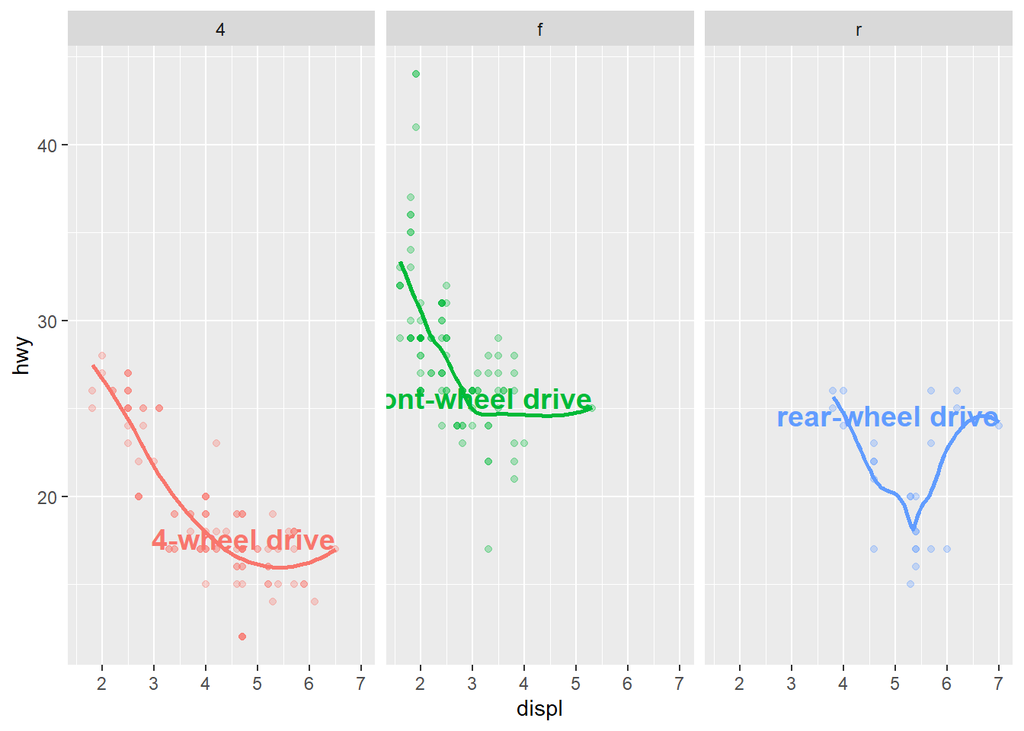

```r
label_info <- mpg |>
  group_by(drv) |>
  arrange(desc(displ)) |>
  slice_head(n = 1) |>
  mutate(
    drive_type = case_when(
      drv == "f" ~ "front-wheel drive",
      drv == "r" ~ "rear-wheel drive",
      drv == "4" ~ "4-wheel drive"
    )
  ) |>
  select(displ, hwy, drv, drive_type)

ggplot(mpg, aes(x = displ, y = hwy, color = drv)) +
  geom_point(alpha = 0.3) +
  geom_smooth(se = FALSE) +
  facet_wrap(~drv) +
  geom_text(
    data = label_info,
    aes(x = displ, y = hwy, label = drive_type),
    fontface = "bold", size = 5, hjust = "right", vjust = "bottom"
  ) +
  theme(legend.position = "none")
```

```r
# In this example it appears to act as expected. We get a single label for each subplot. There is some problems with the small x-axis causing some of the label text to be chopped off (Front-wheel drive). Lets see about fixing this
```

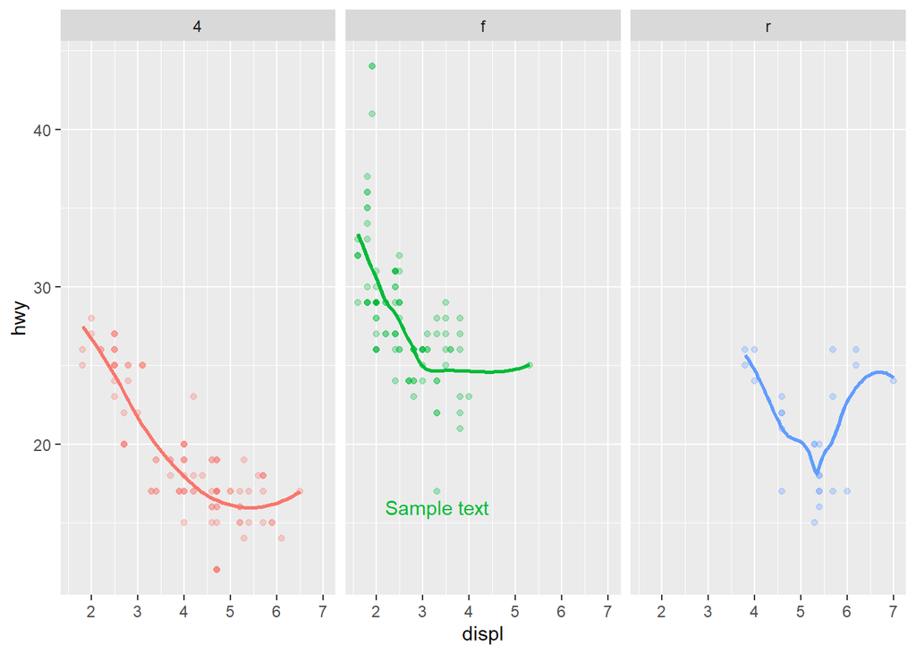

```r
# We can add a single label to a facet by creating our desired dataframe:
single_label <- data.frame(displ = 3.3, hwy = 16, lab = "Sample text", drv = "f")

ggplot(mpg, aes(x = displ, y = hwy, color = drv)) +
  geom_point(alpha = 0.3) +
  geom_smooth(se = FALSE) +
  facet_wrap(~drv) +
  geom_text(
    data = single_label,
    label = single_label$lab
  ) +
  theme(legend.position = "none")
```

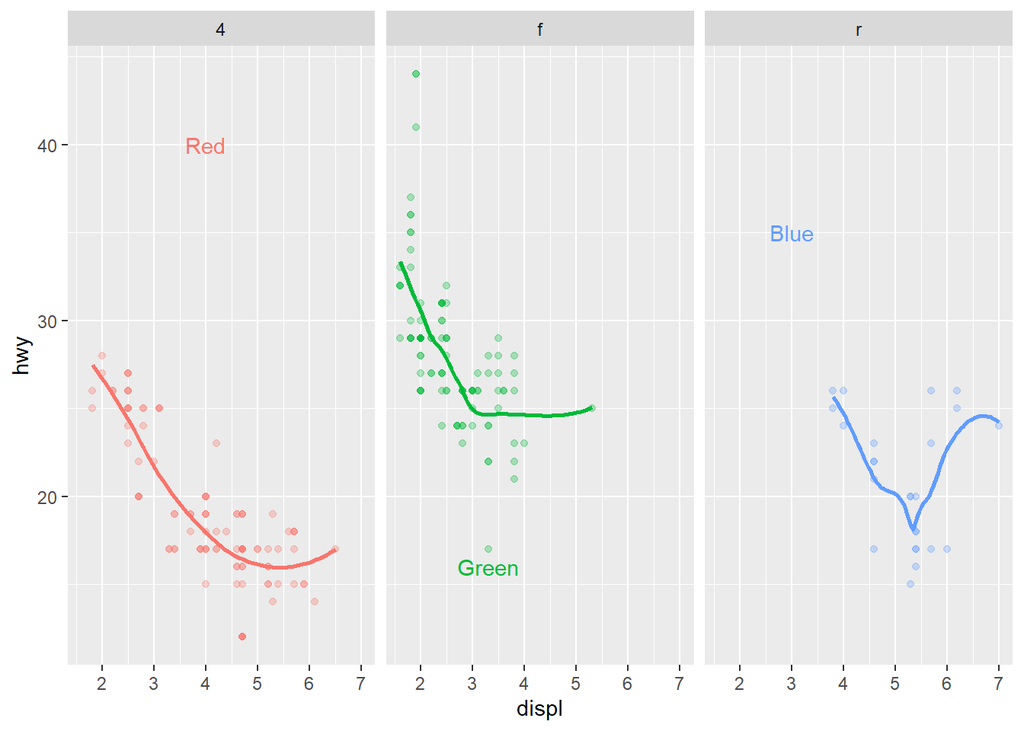

```r
# This can be expanded to include multiple different labels:
multiple_labels <- data.frame(displ = c(4, 3.3, 3), hwy = c(40, 16, 35),
                              lab = c("Red", "Green", "Blue"), drv = c("4", "f", "r"))

ggplot(mpg, aes(x = displ, y = hwy, color = drv)) +
  geom_point(alpha = 0.3) +
  geom_smooth(se = FALSE) +
  facet_wrap(~drv) +
  geom_text(
    data = multiple_labels,
    label = multiple_labels$lab
  ) +
  theme(legend.position = "none")
```

4. What arguments to geom_label() control the appearance of the background box?

Its `fill` I imagine

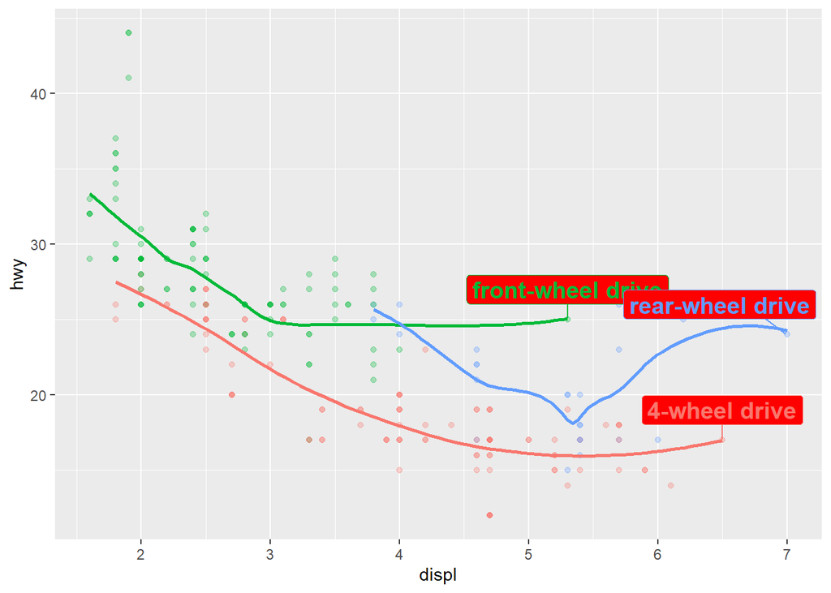

```r
# Look above for label_info
ggplot(mpg, aes(x = displ, y = hwy, color = drv)) +
  geom_point(alpha = 0.3) +
  geom_smooth(se = FALSE) +
  geom_label_repel(
    data = label_info,
    aes(x = displ, y = hwy, label = drive_type),
    fontface = "bold", size = 5, nudge_y = 2, fill = "red"
  ) +
  theme(legend.position = "none")
```

5. What are the four arguments to arrow()? How do they work? Create a series of plots that demonstrate the most important options.

They are `angle`, `length`, `ends` and `type`

`angle` controls the angle between the diagonal lines of the arrow and its base line `length` controls the length of the diagonal lines of the arrow in inches `ends` describes where to position the arrow head. Options of `"last"`, `"first"`, or `"both"` `type` describes if the arrow head should or shouldn’t be a closed triangle. Options of `"open"` or `"closed"`

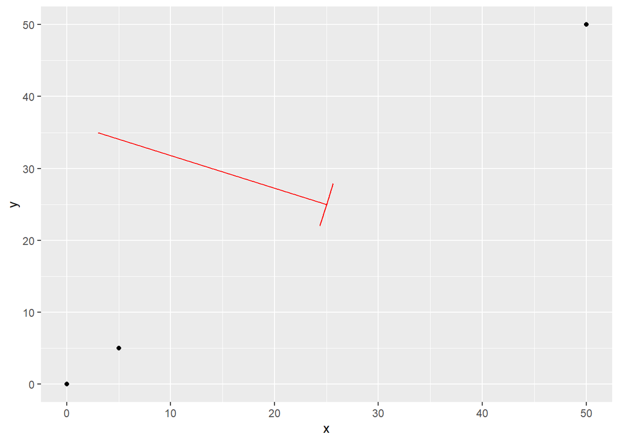

```r
data <- data.frame(
  x = c(0, 50, 5, 5),
  y = c(0, 50, 5, 5)
)

ggplot(data, aes(x, y)) +
  geom_point() +
  annotate(
    geom = "segment",
    x = 3, y = 35, xend = 25, yend = 25, color = "red",
    arrow = arrow(angle = 90)
  )
```

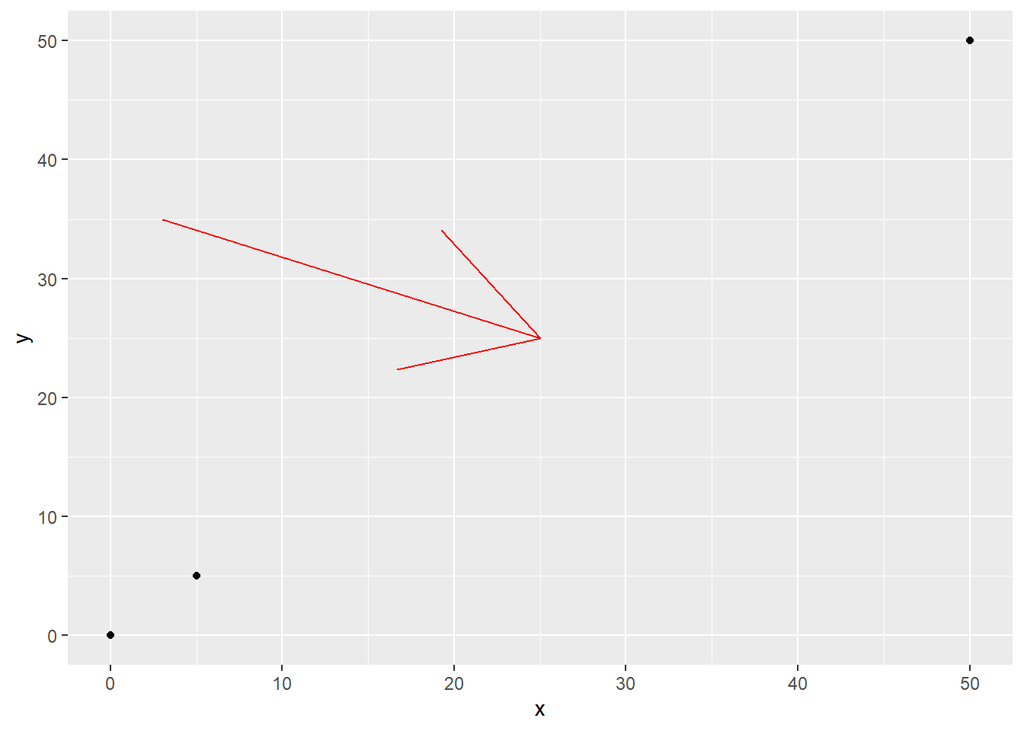

```r
ggplot(data, aes(x, y)) +
  geom_point() +
  annotate(
    geom = "segment",
    x = 3, y = 35, xend = 25, yend = 25, color = "red",
    arrow = arrow(length = unit(1, "inches"))
  )
```

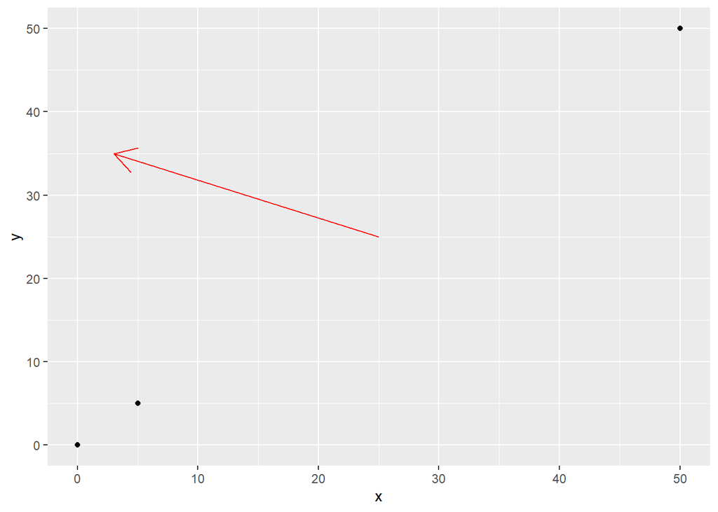

```r
ggplot(data, aes(x, y)) +
  geom_point() +
  annotate(
    geom = "segment",
    x = 3, y = 35, xend = 25, yend = 25, color = "red",
    arrow = arrow(ends = "first")
  )
```

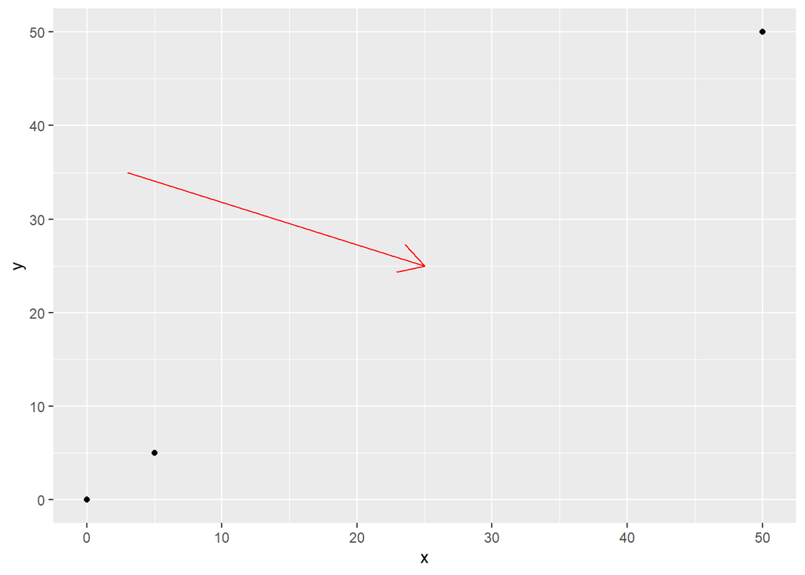

```r
ggplot(data, aes(x, y)) +
  geom_point() +
  annotate(
    geom = "segment",
    x = 3, y = 35, xend = 25, yend = 25, color = "red",
    arrow = arrow(type = "open")
  )
```

## Communication - Scales

1. Why doesn’t the following code override the default scale?

[figure not shown]

```r
df <- tibble(
  x = rnorm(10000),
  y = rnorm(10000)
)

ggplot(df, aes(x, y)) +
  geom_hex() +
  scale_color_gradient(low = "white", high = "red") +
  coord_fixed()
```

[figure not shown]

```r
# Since we are using `geom_hex` we need to use a fill gradient for continuous color

ggplot(df, aes(x, y)) +
  geom_hex() +
  scale_fill_gradient(low = "white", high = "red") +
  coord_fixed()
```

2. What is the first argument to every scale? How does it compare to labs()?

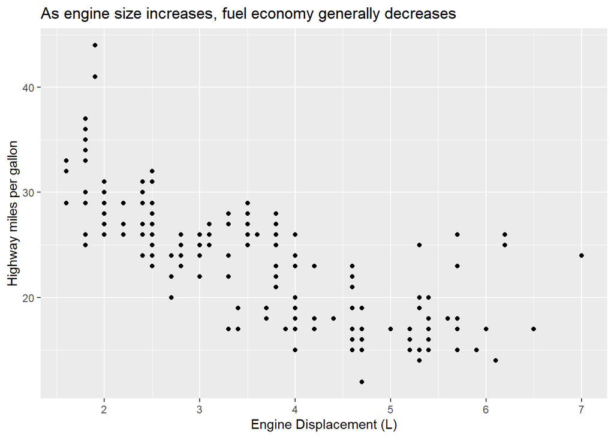

```r
# The first argument to every scale is the label of the scale (e.g. are we making changes to x axis, size, shape etc.?) For labs we have to similarly specify this but inside of the function instead.

ggplot(mpg, aes(displ, hwy)) +
  geom_point() +
  labs(
    title = "As engine size increases, fuel economy generally decreases",
    x = "Engine Displacement (L)",
    y = "Highway miles per gallon"
  )
```

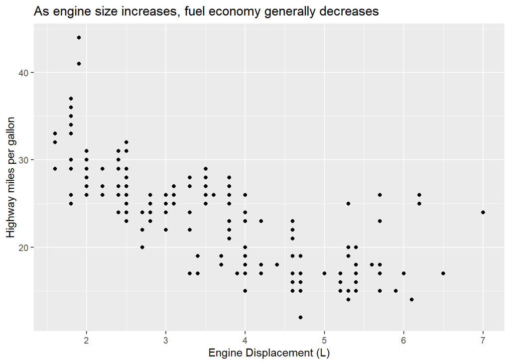

```r
ggplot(mpg, aes(displ, hwy)) +
  geom_point() +
  scale_x_continuous("Engine Displacement (L)") +
  scale_y_continuous("Highway miles per gallon") +
  labs(title = "As engine size increases, fuel economy generally decreases")
```

3. Change the display of the presidential terms by:
1. Combining the two variants that customize colors and x axis breaks.

Simply add `scale_x_date` from the first variant to the second variant.

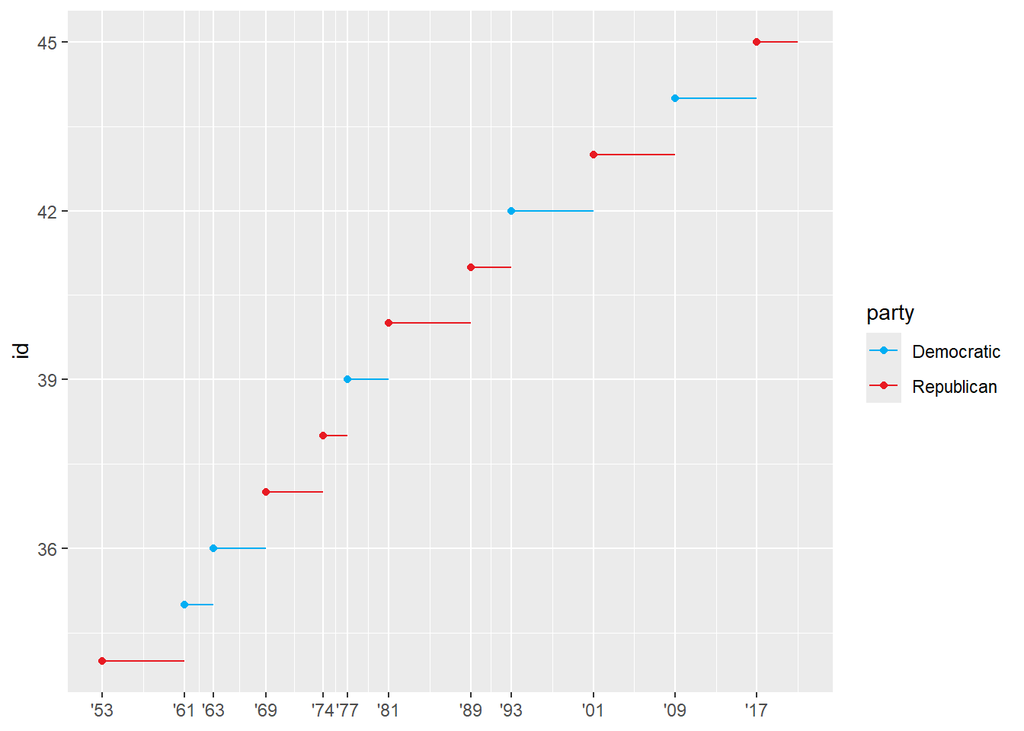

```r
presidential |>
  mutate(id = 33 + row_number()) |>
  ggplot(aes(x = start, y = id, color = party)) +
  geom_point() +
  geom_segment(aes(xend = end, yend = id)) +
  scale_color_manual(values = c(Republican = "#E81B23", Democratic = "#00AEF3")) +
  scale_x_date(name = NULL, breaks = presidential$start, date_labels = "'%y")
```

2. Improving the display of the y axis.

Should try putting the presidents name corresponding to each segment.

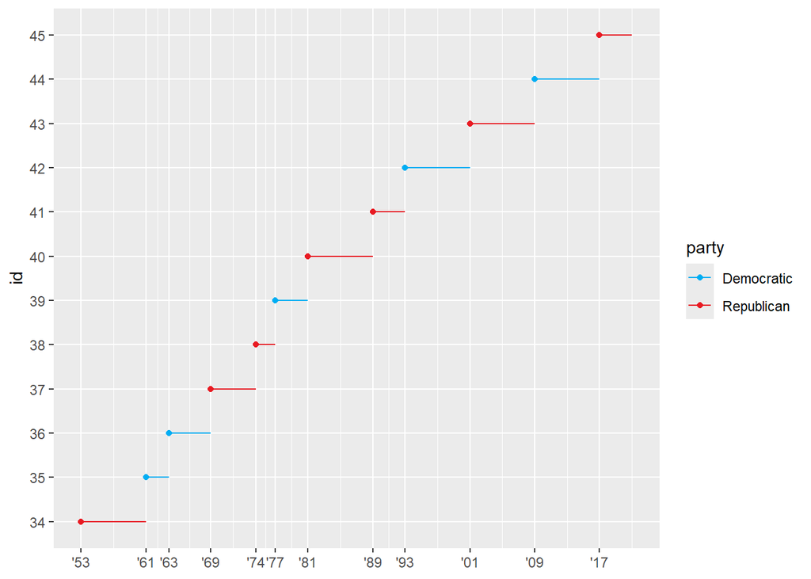

```r
presidential |>
  mutate(id = as.factor(33 + row_number())) |>
  ggplot(aes(x = start, y = id, color = party)) +
  geom_point() +
  geom_segment(aes(xend = end, yend = id)) +
  scale_color_manual(values = c(Republican = "#E81B23", Democratic = "#00AEF3")) +
  scale_x_date(name = NULL, breaks = presidential$start, date_labels = "'%y")
```

```r
# I'm not sure why the axis ticks go up in values of 3 only. This code is essentially identical to part c) just `id` is replaced with `name_id`. The only difference that might be making this weird change is that name_id is a factor while id is double...? So I changed id to a factor and it appears to work now as intended. There is likely a better way to do this.
```

3. Labelling each term with the name of the president.

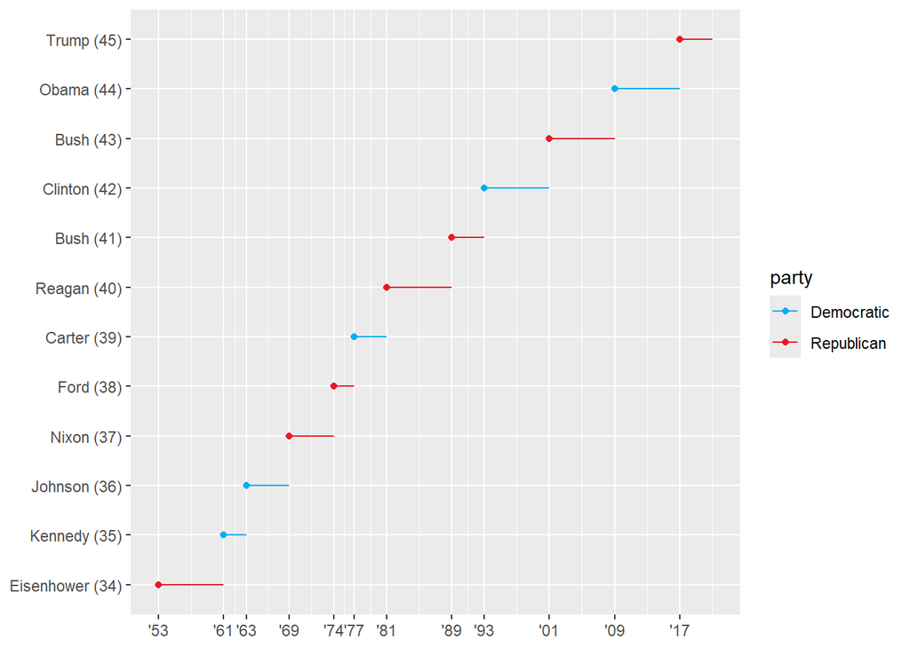

```r
presidential |>
  mutate(
    id = 33 + row_number(),
    name_id = fct_inorder(str_c(name, " (", id, ")"))
    ) |>
  ggplot(aes(x = start, y = name_id, color = party)) +
  geom_point() +
  geom_segment(aes(xend = end, yend = name_id)) +
  scale_color_manual(values = c(Republican = "#E81B23", Democratic = "#00AEF3")) +
  scale_x_date(name = NULL, breaks = presidential$start, date_labels = "'%y") +
  scale_y_discrete(NULL) # Get rid of the `name_id` axis name
```

4. Adding informative plot labels.

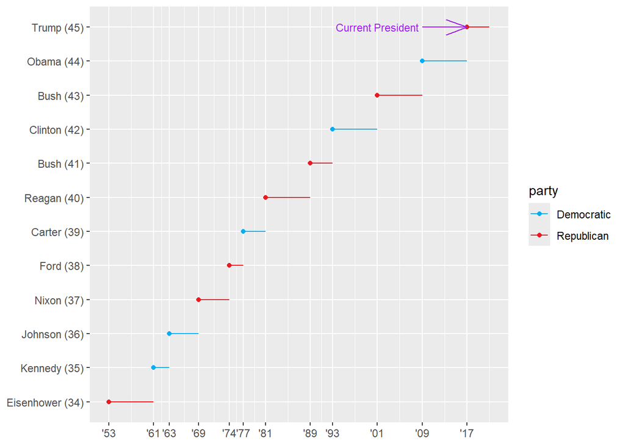

```r
new_presidential <- presidential |>
  mutate(
    id = 33 + row_number(),
    name_id = fct_inorder(str_c(name, " (", id, ")"))
    )

new_presidential |>
  ggplot(aes(x = start, y = name_id, color = party)) +
  geom_point() +
  geom_segment(aes(xend = end, yend = name_id)) +
  scale_color_manual(values = c(Republican = "#E81B23", Democratic = "#00AEF3")) +
  scale_x_date(name = NULL, breaks = presidential$start, date_labels = "'%y") +
  scale_y_discrete(NULL) +
  annotate(
    geom = "segment",
    x = presidential$start[11], y = (45 - 33), xend = presidential$start[12], yend = (45 - 33),
    colour = "purple",
    arrow = arrow(type = "open", angle = 20,)
  ) + # Remember that the y-axis actually goes from 1 to 12, so the y-axis tick labels may be misleading
  annotate(
    geom = "text",
    x = new_presidential$start[10], y = (45 - 33), label = "Current President",
    size = 3, colour = "purple"
  )
```

5. Placing breaks every 4 years (this is trickier than it seems!).

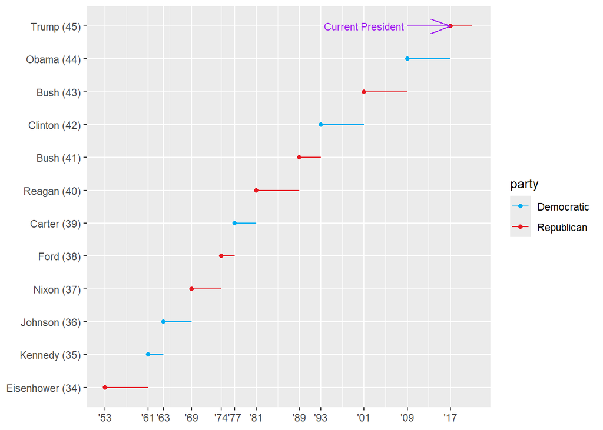

```r
four_years <- seq.Date(from = presidential$start[1], to = tail(presidential$start, 1), by = 365 * 4)
# There is a better way of doing the above using lubridate package in `graphics-for-communication.Rmd` under the first edition solutions to this book

new_presidential |>
  ggplot(aes(x = start, y = name_id, color = party)) +
  geom_point() +
  geom_segment(aes(xend = end, yend = name_id)) +
  scale_color_manual(values = c(Republican = "#E81B23", Democratic = "#00AEF3")) +
  scale_x_date(name = NULL, breaks = presidential$start, date_labels = "'%y",
               minor_breaks = four_years) +
  scale_y_discrete(NULL) +
  annotate(
    geom = "segment",
    x = presidential$start[11], y = (45 - 33), xend = presidential$start[12], yend = (45 - 33),
    colour = "purple",
    arrow = arrow(type = "open", angle = 20,)
  ) +
  annotate(
    geom = "text",
    x = new_presidential$start[10], y = (45 - 33), label = "Current President",
    size = 3, colour = "purple"
  )
```

4. First, create the following plot. Then, modify the code using override.aes to make the legend easier to see.

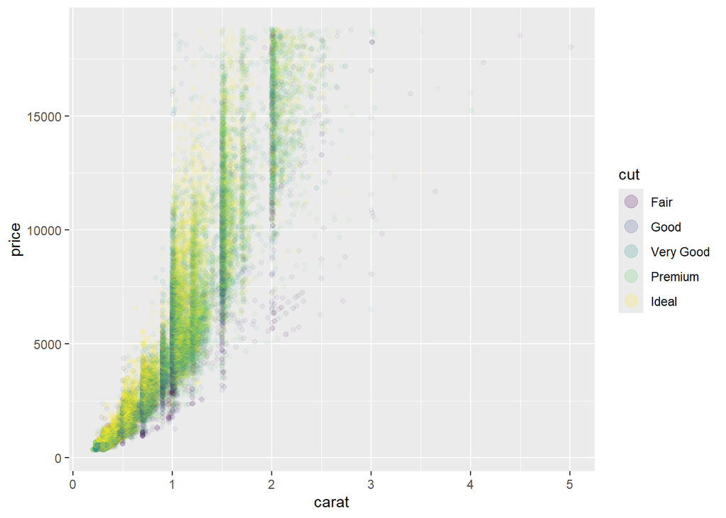

```r
ggplot(diamonds, aes(x = carat, y = price)) +
  geom_point(aes(color = cut), alpha = 1/20) +
  guides(color = guide_legend(override.aes = list(size = 4, alpha = 1/5)))
```

## Communication - Themes

1. Pick a theme offered by the ggthemes package and apply it to the last plot you made.

Answer: Lets apply it to the presidential plot we last made

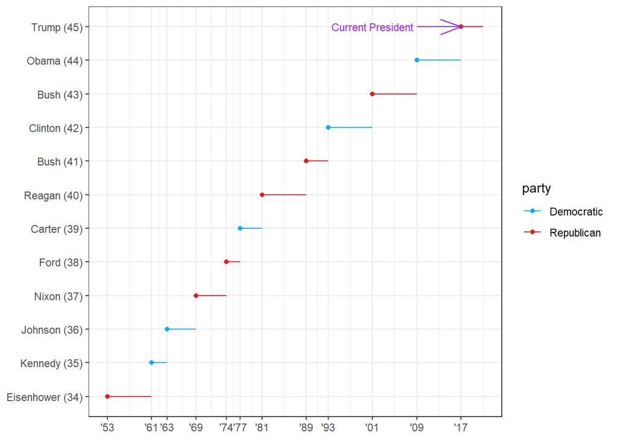

```r
new_presidential <- presidential |>
  mutate(
    id = 33 + row_number(),
    name_id = fct_inorder(str_c(name, " (", id, ")"))
    )

new_presidential |>
  ggplot(aes(x = start, y = name_id, color = party)) +
  geom_point() +
  geom_segment(aes(xend = end, yend = name_id)) +
  scale_color_manual(values = c(Republican = "#E81B23", Democratic = "#00AEF3")) +
  scale_x_date(name = NULL, breaks = presidential$start, date_labels = "'%y") +
  scale_y_discrete(NULL) +
  annotate(
    geom = "segment",
    x = presidential$start[11], y = (45 - 33), xend = presidential$start[12], yend = (45 - 33),
    colour = "purple",
    arrow = arrow(type = "open", angle = 20,)
  ) + # Remember that the y-axis actually goes from 1 to 12, so the y-axis tick labels may be misleading
  annotate(
    geom = "text",
    x = new_presidential$start[10], y = (45 - 33), label = "Current President",
    size = 3, colour = "purple"
  ) +
  theme_bw()
```

```r
# Looks quite nice now. One thing I would change is whether that "Current President" label is even necessary. The least we can do is change the arrowhead so its not directly ontop of the red point denoting Trump's start term.
```

2. Make the axis labels of your plot blue and bolded.

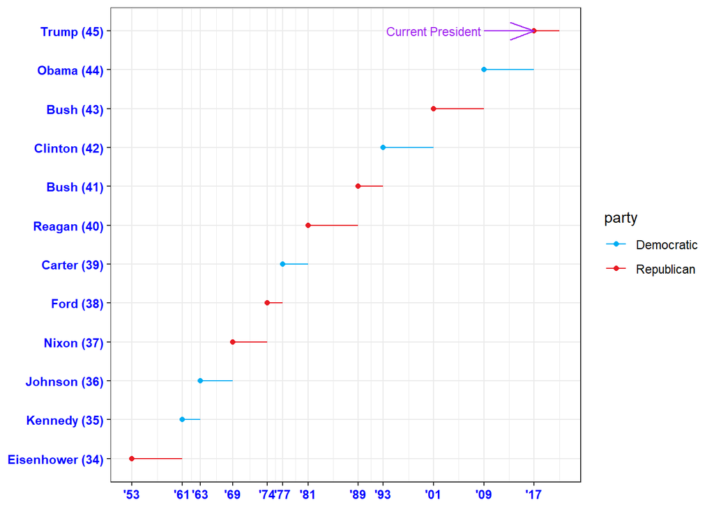

```r
new_presidential |>
  ggplot(aes(x = start, y = name_id, color = party)) +
  geom_point() +
  geom_segment(aes(xend = end, yend = name_id)) +
  scale_color_manual(values = c(Republican = "#E81B23", Democratic = "#00AEF3")) +
  scale_x_date(name = NULL, breaks = presidential$start, date_labels = "'%y") +
  scale_y_discrete(NULL) +
  annotate(
    geom = "segment",
    x = presidential$start[11], y = (45 - 33), xend = presidential$start[12], yend = (45 - 33),
    colour = "purple",
    arrow = arrow(type = "open", angle = 20,)
  ) + # Remember that the y-axis actually goes from 1 to 12, so the y-axis tick labels may be misleading
  annotate(
    geom = "text",
    x = new_presidential$start[10], y = (45 - 33), label = "Current President",
    size = 3, colour = "purple"
  ) +
  theme_bw() +
  theme(axis.text = element_text(colour = "blue", face = "bold"))
```